# Vignette: correlated predictors

DSCI 632: Statistics for Data Science

Peter Ralph

# A very simple example

Here’s some data:

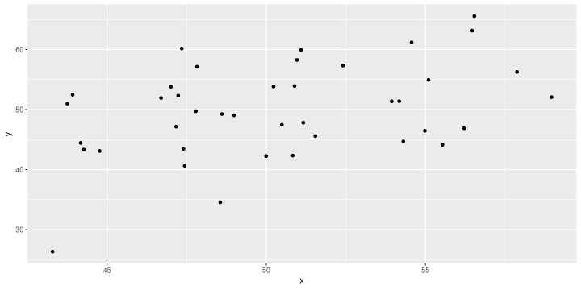

And let’s fit a model:

```r
lm(y ~ x, data=adf) |> summary()
```

```
##
## Call:
## lm(formula = y ~ x, data = adf)
##
## Residuals:
##      Min       1Q   Median       3Q      Max
## -18.3374  -4.5081  -0.1363   5.8999  12.4700
##
## Coefficients:
##             Estimate Std. Error t value Pr(>|t|)
## (Intercept)  12.7544    13.5562   0.941  0.35272
## x             0.7379     0.2682   2.751  0.00905 **
## ---
## Signif. codes:  0 '***' 0.001 '**' 0.01 '*' 0.05 '.' 0.1 ' ' 1
##
## Residual standard error: 7.166 on 38 degrees of freedom
## Multiple R-squared:  0.1661, Adjusted R-squared:  0.1441
## F-statistic: 7.568 on 1 and 38 DF,  p-value: 0.009051
```

```r
abm <- brm(y ~ x, data=adf)
```

## Joint posteriors:

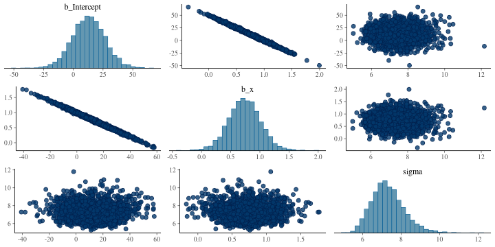

```r
pairs(abm)
```

## What’s going on?

Here are samples of the relationship from the posterior:

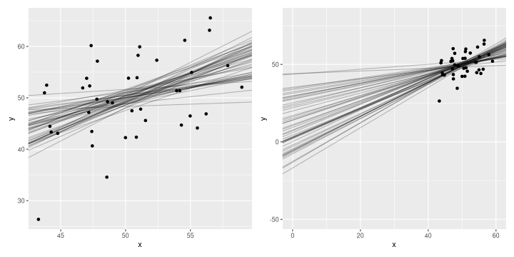

```r
p1 <- adf |> ggplot(aes(x=x, y=y)) +
    geom_abline(data=as_draws_df(abm) |> head(50), mapping=aes(intercept=b_Intercept, slope=b_x), alpha=0.25) +
    geom_point()
p1 | p1 + lims(x=c(0, 60), y=c(-50, 80))
```

# Cartoon example:

## Proxies

Suppose there’s a single underlying variable (`xy`) that is a good predictor of our response (`z`), but we don’t directly observe it, we just observe two equally noisy proxies for it (`x` and `y`):

```r
n <- 200
df <- data.frame(
            xy=rnorm(n, mean=5, sd=2)
) |> mutate(
    x = xy + rnorm(n, sd=0.05),
    y = xy + rnorm(n, sd=0.05),
    z = 3 * xy + 5 + rnorm(n, sd=1)
)
df
```

```
##             xy          x          y         z
## 1   5.02202704 5.05732156 5.02503509 18.919990
## 2   6.25748820 6.21024265 6.24286936 22.668037
## 3   8.95212664 8.97370385 9.04217022 31.398616
## 4   5.92311642 5.96106974 5.97915453 22.379162
## 5   6.05203228 6.04688451 6.03681034 22.700792
## 6   0.89963360 0.90283951 0.90390480  8.655815
## 7   3.89833285 3.92535857 3.93284868 15.868239
## 8   3.84145010 3.84160583 3.78268098 16.403067
## 9   6.05628795 6.05005591 6.02057830 21.645224
## 10  4.72049258 4.71254600 4.70710125 18.190412
## 11  8.09187571 8.12620678 7.96349305 30.289391
## 12  7.34747375 7.26196441 7.39507793 27.189457
## 13  6.27988131 6.36366663 6.26375229 22.831757
## 14  4.90296324 4.90720097 4.91334072 18.361039
```

[output cut: 186 more lines]

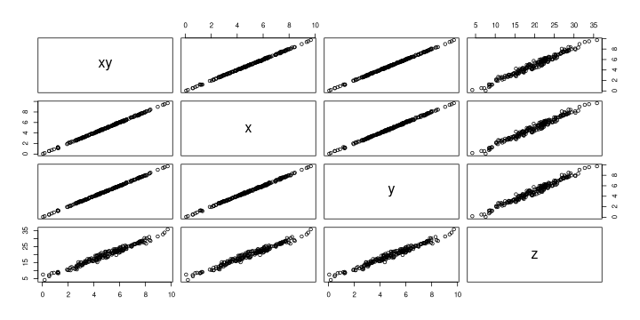

```r
pairs(df)
```

We don’t know this, of course, so we fit a model with both.

```r
lm(z ~ x + y, data=df) |> summary()
```

```
##
## Call:
## lm(formula = z ~ x + y, data = df)
##
## Residuals:
##     Min      1Q  Median      3Q     Max
## -2.6160 -0.6325 -0.0531  0.5481  2.2467
##
## Coefficients:
##             Estimate Std. Error t value Pr(>|t|)
## (Intercept)   5.1229     0.1974  25.958  < 2e-16 ***
## x             2.5660     0.9625   2.666  0.00831 **
## y             0.4185     0.9643   0.434  0.66477
## ---
## Signif. codes:  0 '***' 0.001 '**' 0.01 '*' 0.05 '.' 0.1 ' ' 1
##
## Residual standard error: 1.01 on 197 degrees of freedom
## Multiple R-squared:  0.9706, Adjusted R-squared:  0.9703
## F-statistic:  3249 on 2 and 197 DF,  p-value: < 2.2e-16
```

But! beware when interpreting coefficients!

```r
lm(z ~ x, data=df) |> summary()
```

```
##
## Call:
## lm(formula = z ~ x, data = df)
##
## Residuals:
##      Min       1Q   Median       3Q      Max
## -2.57011 -0.63196 -0.05709  0.55985  2.24367
##
## Coefficients:
##             Estimate Std. Error t value Pr(>|t|)
## (Intercept)  5.12741    0.19668   26.07   <2e-16 ***
## x            2.98343    0.03693   80.78   <2e-16 ***
## ---
## Signif. codes:  0 '***' 0.001 '**' 0.01 '*' 0.05 '.' 0.1 ' ' 1
##
## Residual standard error: 1.008 on 198 degrees of freedom
## Multiple R-squared:  0.9705, Adjusted R-squared:  0.9704
## F-statistic:  6525 on 1 and 198 DF,  p-value: < 2.2e-16
```

And then maybe we do some model selection: do we need both predictors?

```r
anova(
    lm(z ~ x * y, data=df),
    lm(z ~ x + y, data=df),
    lm(z ~ x, data=df)
)
```

```
## Analysis of Variance Table
##
## Model 1: z ~ x * y
## Model 2: z ~ x + y
## Model 3: z ~ x
##   Res.Df    RSS Df Sum of Sq      F Pr(>F)
## 1    196 201.02
## 2    197 201.04 -1 -0.012895 0.0126 0.9108
## 3    198 201.23 -1 -0.192205 0.1874 0.6656
```

Let’s see what brms tells us about the situation:

```r
bmod <- brm(z ~ x + y, data=df)
summary(bmod)
```

[output not shown]

Here’s the important bit: we are pretty uncertain about both `b_x` and `b_y`, but we’re *quite* certain about *something*:

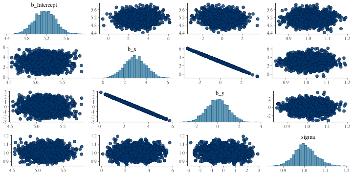

```r
pairs(bmod)
```

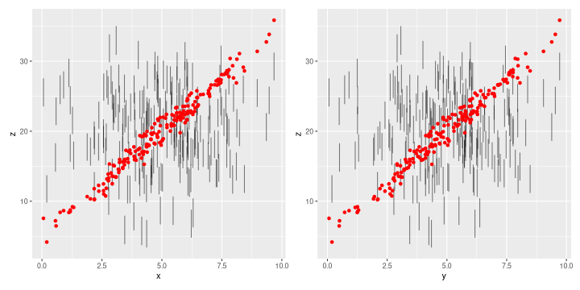

```r
preds <- cbind(df, predict(bmod))
p1 <- preds |> ggplot(aes(x=x)) +
    geom_linerange(aes(ymin=Q2.5, ymax=Q97.5), alpha=0.5) +
    geom_point(aes(y=z), color='red')
p2 <- preds |> ggplot(aes(x=y)) +
    geom_linerange(aes(ymin=Q2.5, ymax=Q97.5), alpha=0.5) +
    geom_point(aes(y=z), color='red')
p1 | p2
```

Always ask: where do we actually have *data*?

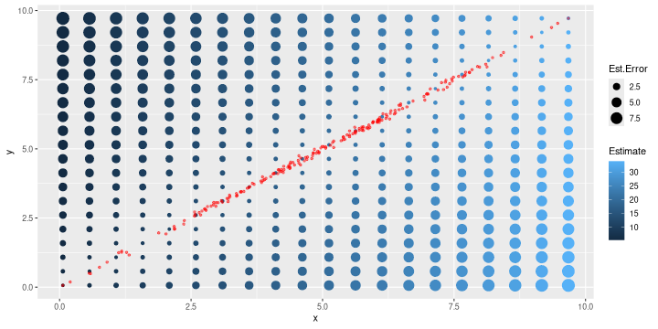

```r
xyz <- expand.grid(
    x=seq(min(df$x), max(df$x), length.out=20),
    y=seq(min(df$y), max(df$y), length.out=20)
)
xyz <- cbind(xyz, predict(bmod, newdata=xyz))
xyz |> ggplot(aes(x=x, y=y, size=Est.Error, color=Estimate)) + geom_point() +
    geom_point(data=df, size=1, color='red', alpha=0.5)
```

We are uncertain about the coefficients because it’s the slope across here:

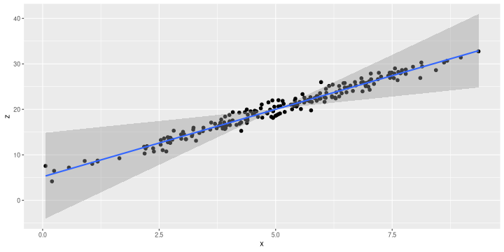

```r
p1 <- xyz |> ggplot(aes(x=x, y=y, size=Est.Error, color=Estimate)) + geom_point() +
    geom_abline(intercept=mean(df$y), slope=0, col='grey', linewidth=2)
p2 <- conditional_effects(bmod, effects="x") |> plot(points=TRUE)
```

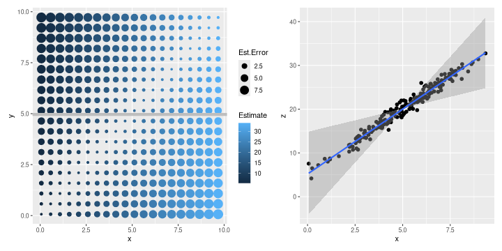

```r
p1 | p2[[1]]
```

# Empirical example: what is “size”, anyways?

## On the number of babies

Let’s look back at the PanTHERIA dataset:

```r
source("../datasets/PanTHERIA/read_pantheria.R")
pantheria <- read_pantheria("../datasets/PanTHERIA") |>
    filter(!is.na(AdultBodyMass_g) & !is.na(AdultHeadBodyLen_mm)) |>
    select(Order, Family, Genus, Species, AdultBodyMass_g, AdultHeadBodyLen_mm, LitterSize, BasalMetRate_mLO2hr)
head(pantheria)
```

```
##          Order  Family Genus   Species AdultBodyMass_g AdultHeadBodyLen_mm LitterSize BasalMetRate_mLO2hr
## 1    Carnivora Canidae Canis   adustus        10392.49              745.32       4.50                  NA
## 2    Carnivora Canidae Canis    aureus         9658.70              827.53       3.74                  NA
## 3    Carnivora Canidae Canis   latrans        11989.10              872.39       5.72              3699.0
## 4    Carnivora Canidae Canis     lupus        31756.51             1055.00       4.98             11254.2
## 5 Artiodactyla Bovidae   Bos frontalis       800143.05             2700.00       1.22                  NA
## 6 Artiodactyla Bovidae   Bos javanicus       635974.34             2075.00       1.22                  NA
```

## A question:

How does metabolic rate correlate with mammal size? Well, let’s see:

```r
lm( log(BasalMetRate_mLO2hr) ~ log(AdultBodyMass_g) * log(AdultHeadBodyLen_mm), data=pantheria ) |> summary()
```

```
##
## Call:
## lm(formula = log(BasalMetRate_mLO2hr) ~ log(AdultBodyMass_g) *
##     log(AdultHeadBodyLen_mm), data = pantheria)
##
## Residuals:
##     Min      1Q  Median      3Q     Max
## -2.5047 -0.2134 -0.0018  0.2732  1.1246
##
## Coefficients:
##                                               Estimate Std. Error t value Pr(>|t|)
## (Intercept)                                   0.292040   0.521411   0.560 0.575757
## log(AdultBodyMass_g)                          0.091571   0.071630   1.278 0.201919
## log(AdultHeadBodyLen_mm)                      0.526204   0.142291   3.698 0.000251 ***
## log(AdultBodyMass_g):log(AdultHeadBodyLen_mm) 0.053314   0.008032   6.638 1.15e-10 ***
## ---
## Signif. codes:  0 '***' 0.001 '**' 0.01 '*' 0.05 '.' 0.1 ' ' 1
##
## Residual standard error: 0.4121 on 366 degrees of freedom
##   (1414 observations deleted due to missingness)
## Multiple R-squared:  0.9533, Adjusted R-squared:  0.953
## F-statistic:  2492 on 3 and 366 DF,  p-value: < 2.2e-16
```

## But, what is “size”?

Our predictors are, um, quite similar:

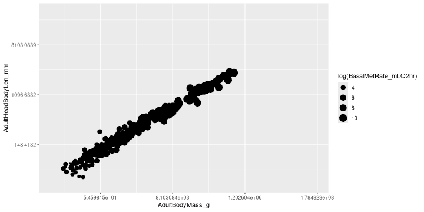

```r
pantheria |> ggplot(aes(x=AdultBodyMass_g, y=AdultHeadBodyLen_mm, size=log(BasalMetRate_mLO2hr))) +
    geom_point() + scale_x_continuous(transform='log') + scale_y_continuous(transform='log')
```

Maybe we didn’t need both of those predictors? Looks like it is improving the model:

```r
anova(
    lm( log(BasalMetRate_mLO2hr) ~ log(AdultBodyMass_g) + log(AdultHeadBodyLen_mm), data=pantheria ),
    lm( log(BasalMetRate_mLO2hr) ~ log(AdultBodyMass_g), subset=!is.na(AdultHeadBodyLen_mm), data=pantheria )
)
```

```
## Analysis of Variance Table
##
## Model 1: log(BasalMetRate_mLO2hr) ~ log(AdultBodyMass_g) + log(AdultHeadBodyLen_mm)
## Model 2: log(BasalMetRate_mLO2hr) ~ log(AdultBodyMass_g)
##   Res.Df    RSS Df Sum of Sq     F    Pr(>F)
## 1    367 69.631
## 2    368 74.562 -1   -4.9311 25.99 5.509e-07 ***
## ---
## Signif. codes:  0 '***' 0.001 '**' 0.01 '*' 0.05 '.' 0.1 ' ' 1
```

## Let’s be Bayesian:

```r
mmod <- brm( log(BasalMetRate_mLO2hr) ~ log(AdultBodyMass_g) * log(AdultHeadBodyLen_mm), data=pantheria )
```

```r
summary(mmod)
```

```
##  Family: gaussian
##   Links: mu = identity
## Formula: log(BasalMetRate_mLO2hr) ~ log(AdultBodyMass_g) * log(AdultHeadBodyLen_mm)
##    Data: pantheria (Number of observations: 370)
##   Draws: 4 chains, each with iter = 2000; warmup = 1000; thin = 1;
##          total post-warmup draws = 4000
##
## Regression Coefficients:
##                                           Estimate Est.Error l-95% CI u-95% CI Rhat Bulk_ESS Tail_ESS
## Intercept                                     0.29      0.53    -0.76     1.31 1.00     2879     2310
## logAdultBodyMass_g                            0.09      0.07    -0.05     0.23 1.00     2294     2289
## logAdultHeadBodyLen_mm                        0.53      0.14     0.24     0.82 1.00     2742     2347
## logAdultBodyMass_g:logAdultHeadBodyLen_mm     0.05      0.01     0.04     0.07 1.00     2516     2431
##
## Further Distributional Parameters:
##       Estimate Est.Error l-95% CI u-95% CI Rhat Bulk_ESS Tail_ESS
## sigma     0.41      0.01     0.39     0.44 1.00     3352     2499
##
## Draws were sampled using sampling(NUTS). For each parameter, Bulk_ESS
## and Tail_ESS are effective sample size measures, and Rhat is the potential
## scale reduction factor on split chains (at convergence, Rhat = 1).
```

Here’s the joint distribution of the posteriors:

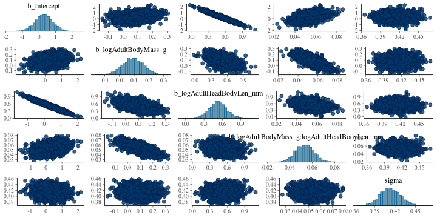

```r
pairs(mmod)
```

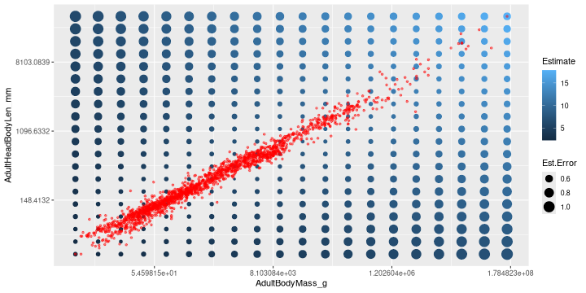

```r
xy <- with(subset(pantheria, !is.na(AdultBodyMass_g) & !is.na(AdultHeadBodyLen_mm)),
    expand.grid(
        AdultBodyMass_g=seq(min(log(AdultBodyMass_g)), max(log(AdultBodyMass_g)), length.out=20) |> exp(),
        AdultHeadBodyLen_mm=seq(min(log(AdultHeadBodyLen_mm)), max(log(AdultHeadBodyLen_mm)), length.out=20) |> exp()
    ) )
xy <- cbind(xy, predict(mmod, newdata=xy))
xy |> ggplot(aes(x=AdultBodyMass_g, y=AdultHeadBodyLen_mm, size=Est.Error, color=Estimate)) + geom_point() +
    geom_point(data=pantheria, size=1, color='red', alpha=0.5) + scale_x_continuous(transform='log') + scale_y_continuous(transform='log')
```

Again, here’s how well we’re predicting *for our data*: (and, note the outliers!)

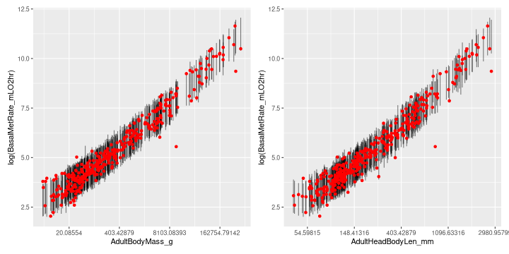

```r
preds <- cbind(mmod$data, predict(mmod))
p1 <- preds |> ggplot(aes(x=AdultBodyMass_g)) +
    geom_linerange(aes(ymin=Q2.5, ymax=Q97.5), alpha=0.5) +
    geom_point(aes(y=log(BasalMetRate_mLO2hr)), color='red') + scale_x_continuous(transform='log')
p2 <- preds |> ggplot(aes(x=AdultHeadBodyLen_mm)) +
    geom_linerange(aes(ymin=Q2.5, ymax=Q97.5), alpha=0.5) +
    geom_point(aes(y=log(BasalMetRate_mLO2hr)), color='red') + scale_x_continuous(transform='log')
p1 | p2
```